# Model averages and ensemble modeling

July 18, 2018

## Ensemble Modeling

- Build a prediction model
  - combine the strengths of basic simpler models together
  - Example:
    - bagging (8.7), random forest (chapter 15)
    - bayesian method for non-parametric regression
- Method has two tasks
  - develop population of base model using training data
  - combine the models for composite prediction
- Why ensemble modeling?
  - reduce prediction variability
  - example: decision trees have high variability
  - when data is large, this helps to fit model in convenient time

## Bagging

- Take \(B\) bootstrap samples from the training data set
- Obtain prediction \(\hat f^b(x)\) from \(b\)th bootstrap sample
- Finally obtain prediction
  - for regression: \[\hat f_{bag}(x) = \frac 1 B \sum_{b=1}^B \hat f^b(x)\]
  - for classification: use majority vote for a class
- OOB error is computed using Out Of Bag data (validation set)
  - training is usually terminated once OOB error stabilizes
- Test error is computed using test data set
- Bagging is very useful for trees. Since trees are less biased with high variability.

## Random Forest

- Similar to bagging
  - but for each tree a random set of \(m\) variables are considered
    - this creates uncorrelated trees for each bootstrap sample
  - in bagging, all the trees are correlated
    - this does not help reduce prediction error
- Choice of \(m\) out of \(p\) explanatory variables
  - classification problem: default \(m = \lfloor \sqrt{p} \rfloor\)
  - regression problem: default \(m = \lfloor p/3 \rfloor\)
  - actual value of \(m\) can be obtained by tuning using validation data set

## Fitting a Decision Tree

```r
library(tree)
library(ISLR)
dat <- Carseats[,-1]
dat$High <- factor(ifelse(Carseats$Sales <= 8,"No","Yes"))
fit.tree <- tree(High ~ . , dat )
summary(fit.tree)
```

```
##
## Classification tree:
## tree(formula = High ~ ., data = dat)
## Variables actually used in tree construction:
## [1] "ShelveLoc"   "Price"       "Income"      "CompPrice"   "Population"
## [6] "Advertising" "Age"         "US"
## Number of terminal nodes:  27
## Residual mean deviance:  0.4575 = 170.7 / 373
## Misclassification error rate: 0.09 = 36 / 400
```

## Displaying the fitted Tree

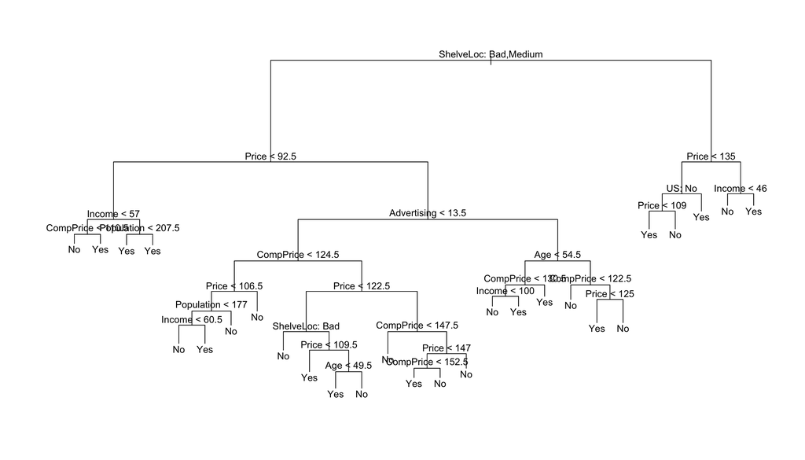

```r
plot(fit.tree)
text(fit.tree ,pretty =0)
```

## Displaying the fitted Tree

```r
fit.tree
```

```
## node), split, n, deviance, yval, (yprob)
##       * denotes terminal node
##
##   1) root 400 541.500 No ( 0.59000 0.41000 )
##     2) ShelveLoc: Bad,Medium 315 390.600 No ( 0.68889 0.31111 )
##       4) Price < 92.5 46  56.530 Yes ( 0.30435 0.69565 )
##         8) Income < 57 10  12.220 No ( 0.70000 0.30000 )
##          16) CompPrice < 110.5 5   0.000 No ( 1.00000 0.00000 ) *
##          17) CompPrice > 110.5 5   6.730 Yes ( 0.40000 0.60000 ) *
##         9) Income > 57 36  35.470 Yes ( 0.19444 0.80556 )
##          18) Population < 207.5 16  21.170 Yes ( 0.37500 0.62500 ) *
##          19) Population > 207.5 20   7.941 Yes ( 0.05000 0.95000 ) *
##       5) Price > 92.5 269 299.800 No ( 0.75465 0.24535 )
##        10) Advertising < 13.5 224 213.200 No ( 0.81696 0.18304 )
##          20) CompPrice < 124.5 96  44.890 No ( 0.93750 0.06250 )
##            40) Price < 106.5 38  33.150 No ( 0.84211 0.15789 )
##              80) Population < 177 12  16.300 No ( 0.58333 0.41667 )
##               160) Income < 60.5 6   0.000 No ( 1.00000 0.00000 ) *
##               161) Income > 60.5 6   5.407 Yes ( 0.16667 0.83333 ) *
##              81) Population > 177 26   8.477 No ( 0.96154 0.03846 ) *
##            41) Price > 106.5 58   0.000 No ( 1.00000 0.00000 ) *
##          21) CompPrice > 124.5 128 150.200 No ( 0.72656 0.27344 )
##            42) Price < 122.5 51  70.680 Yes ( 0.49020 0.50980 )
##              84) ShelveLoc: Bad 11   6.702 No ( 0.90909 0.09091 ) *
##              85) ShelveLoc: Medium 40  52.930 Yes ( 0.37500 0.62500 )
##               170) Price < 109.5 16   7.481 Yes ( 0.06250 0.93750 ) *
##               171) Price > 109.5 24  32.600 No ( 0.58333 0.41667 )
##                 342) Age < 49.5 13  16.050 Yes ( 0.30769 0.69231 ) *
##                 343) Age > 49.5 11   6.702 No ( 0.90909 0.09091 ) *
##            43) Price > 122.5 77  55.540 No ( 0.88312 0.11688 )
##              86) CompPrice < 147.5 58  17.400 No ( 0.96552 0.03448 ) *
##              87) CompPrice > 147.5 19  25.010 No ( 0.63158 0.36842 )
##               174) Price < 147 12  16.300 Yes ( 0.41667 0.58333 )
##                 348) CompPrice < 152.5 7   5.742 Yes ( 0.14286 0.85714 ) *
##                 349) CompPrice > 152.5 5   5.004 No ( 0.80000 0.20000 ) *
##               175) Price > 147 7   0.000 No ( 1.00000 0.00000 ) *
##        11) Advertising > 13.5 45  61.830 Yes ( 0.44444 0.55556 )
##          22) Age < 54.5 25  25.020 Yes ( 0.20000 0.80000 )
##            44) CompPrice < 130.5 14  18.250 Yes ( 0.35714 0.64286 )
##              88) Income < 100 9  12.370 No ( 0.55556 0.44444 ) *
##              89) Income > 100 5   0.000 Yes ( 0.00000 1.00000 ) *
##            45) CompPrice > 130.5 11   0.000 Yes ( 0.00000 1.00000 ) *
##          23) Age > 54.5 20  22.490 No ( 0.75000 0.25000 )
##            46) CompPrice < 122.5 10   0.000 No ( 1.00000 0.00000 ) *
##            47) CompPrice > 122.5 10  13.860 No ( 0.50000 0.50000 )
##              94) Price < 125 5   0.000 Yes ( 0.00000 1.00000 ) *
##              95) Price > 125 5   0.000 No ( 1.00000 0.00000 ) *
##     3) ShelveLoc: Good 85  90.330 Yes ( 0.22353 0.77647 )
##       6) Price < 135 68  49.260 Yes ( 0.11765 0.88235 )
##        12) US: No 17  22.070 Yes ( 0.35294 0.64706 )
##          24) Price < 109 8   0.000 Yes ( 0.00000 1.00000 ) *
##          25) Price > 109 9  11.460 No ( 0.66667 0.33333 ) *
##        13) US: Yes 51  16.880 Yes ( 0.03922 0.96078 ) *
##       7) Price > 135 17  22.070 No ( 0.64706 0.35294 )
##        14) Income < 46 6   0.000 No ( 1.00000 0.00000 ) *
##        15) Income > 46 11  15.160 Yes ( 0.45455 0.54545 ) *
```

## Fitting tree with training data

```r
set.seed (2)
N <- nrow(dat)
train <- sample(1:N, 200)
dat.test <- dat[-train ,]
fit.tree1 <- tree(High ~. , dat, subset=train)
tree.pred <- predict(fit.tree1, dat.test, type="class")
(rs <- table(tree.pred ,dat.test$High))
```

```
##
## tree.pred No Yes
##       No  86  27
##       Yes 30  57
```

```r
(rs[1,1]+rs[2,2]) /sum(rs)
```

```
## [1] 0.715
```

## Improving Tree fit by cross-validation

```r
set.seed(3)
cv.dat <- cv.tree(fit.tree1, FUN = prune.misclass )
cv.dat
```

```
## $size
## [1] 19 17 14 13  9  7  3  2  1
##
## $dev
## [1] 55 55 53 52 50 56 69 65 80
##
## $k
## [1]       -Inf  0.0000000  0.6666667  1.0000000  1.7500000  2.0000000
## [7]  4.2500000  5.0000000 23.0000000
##
## $method
## [1] "misclass"
##
## attr(,"class")
## [1] "prune"         "tree.sequence"
```

## Showing cross-validation result

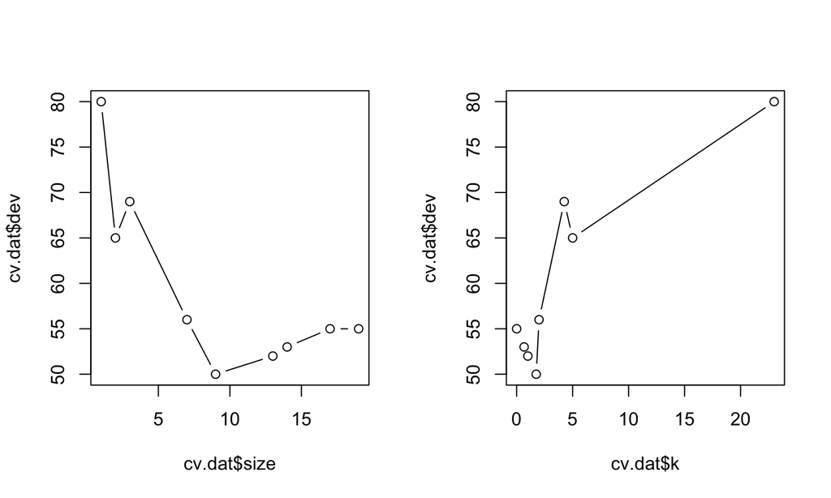

```r
par(mfrow=c(1,2))
plot(cv.dat$size ,cv.dat$dev ,type="b")
plot(cv.dat$k ,cv.dat$dev ,type="b")
```

## Pruning the tree

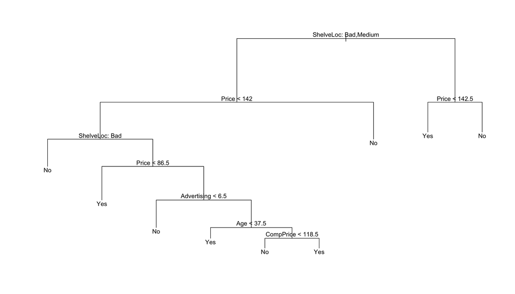

```r
prune.tree <- prune.misclass(fit.tree1, best = 9)
plot(prune.tree)
text(prune.tree,pretty=0)
```

## Results after pruning

```r
tree.pred <- predict(prune.tree, dat.test, type="class")
(rs <- table(tree.pred ,dat.test$High))
```

```
##
## tree.pred No Yes
##       No  94  24
##       Yes 22  60
```

```r
(rs[1,1]+rs[2,2]) /sum(rs)
```

```
## [1] 0.77
```

## Fitting Random Forest

```r
library(randomForest)
set.seed(1)
fit.rf <- randomForest(High ~. , dat, subset=train, mtry = 7, importance =TRUE)
fit.rf
```

```
##
## Call:
##  randomForest(formula = High ~ ., data = dat, mtry = 7, importance = TRUE,      subset = train)
##                Type of random forest: classification
##                      Number of trees: 500
## No. of variables tried at each split: 7
##
##         OOB estimate of  error rate: 20.5%
## Confusion matrix:
##      No Yes class.error
## No  107  13   0.1083333
## Yes  28  52   0.3500000
```

## Fitting Random Forest

```r
(rs <- fit.rf$confusion)
```

```
##      No Yes class.error
## No  107  13   0.1083333
## Yes  28  52   0.3500000
```

```r
(rs[1,1]+rs[2,2]) /sum(rs)
```

```
## [1] 0.7931823
```

## Fitting Random Forest

```r
fit.rf <- randomForest(High ~. , dat, subset=train, mtry = 3, ntree = 500,
                       importance =TRUE)
fit.rf
```

```
##
## Call:
##  randomForest(formula = High ~ ., data = dat, mtry = 3, ntree = 500,      importance = TRUE, subset = train)
##                Type of random forest: classification
##                      Number of trees: 500
## No. of variables tried at each split: 3
##
##         OOB estimate of  error rate: 20%
## Confusion matrix:
##      No Yes class.error
## No  108  12        0.10
## Yes  28  52        0.35
```

## Tuning Random Forest

```r
res <- tuneRF(x = dat[-train,-11], y = dat[-train,11], stepFactor=1.5,
              trace=FALSE, ntreeTry=500, plot=FALSE)
```

```
## 0.1351351 0.05
## -0.09375 0.05
```

```r
print(res)
```

```
##       mtry OOBError
## 2.OOB    2    0.160
## 3.OOB    3    0.185
## 4.OOB    4    0.175
```

```r
fit.rf <- randomForest(High ~. , dat, subset=train, mtry = 4, ntree = 500,
                       importance =TRUE)
fit.rf
```

```
##
## Call:
##  randomForest(formula = High ~ ., data = dat, mtry = 4, ntree = 500,      importance = TRUE, subset = train)
##                Type of random forest: classification
##                      Number of trees: 500
## No. of variables tried at each split: 4
##
##         OOB estimate of  error rate: 20%
## Confusion matrix:
##      No Yes class.error
## No  109  11  0.09166667
## Yes  29  51  0.36250000
```

## Fitting Random Forest

```r
(rs <- fit.rf$confusion)
```

```
##      No Yes class.error
## No  109  11  0.09166667
## Yes  29  51  0.36250000
```

```r
(rs[1,1]+rs[2,2]) /sum(rs)
```

```
## [1] 0.7981874
```

## Importance of the variable

```r
importance(fit.rf)
```

```
##                      No         Yes MeanDecreaseAccuracy MeanDecreaseGini
## CompPrice    4.29041655 -0.59686496            2.9159575         9.417723
## Income      -2.41800171 -3.74584899           -4.2245687         7.816990
## Advertising 11.20274721 10.13247101           14.0250310        11.599761
## Population  -0.01590727 -1.28549151           -0.8963706         8.946784
## Price       24.91213619 17.26968687           27.8740529        23.289391
## ShelveLoc   21.61656857 19.06867291           26.0475220        15.277164
## Age          7.49587968  2.90265825            7.5282474        12.091158
## Education   -0.90971675 -3.32277397           -2.7034216         4.579599
## Urban        0.84108015 -0.43336625            0.4677450         1.305782
## US           2.42167052 -0.04039738            1.8226839         1.163468
```

## Importance of the variable

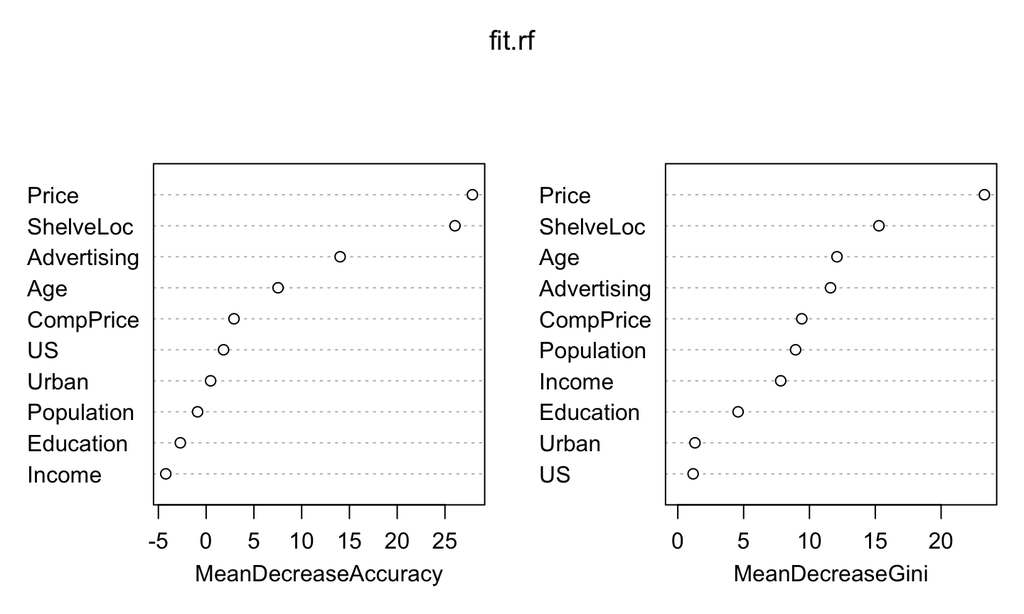

```r
varImpPlot (fit.rf)
```

## Homework Problem

In this lecture, a classification tree was applied to the `Carseats` data set after converting Sales into a qualitative response (factor) variable. Now we will seek to predict Sales using regression trees and related approaches, treating the response as a quantitative variable.

1. Split the data set into a training set and a test set.
2. Fit a regression tree to the training set. Plot the tree, and interpret the results. What test MSE do you obtain?
3. Use cross-validation in order to determine the optimal level of tree complexity. Does pruning the tree improve the test MSE?
4. Use the bagging approach in order to analyze this data. What test MSE do you obtain? Use the `importance()` function to determine which variables are most important.
5. Use random forests to analyze this data as well

## Reading and References

- Chapters 15, 16, The Elements of Statistical Learning by Hastie at el.
  - to obtain the data in this book install R package `ElemStatLearn`
- An Introduction to Statistical Learning with Applications in R by Casella at el.